# Final Supplement Sales Analysis

**Created by "Harianto .T" At 04 March 2024 03:00 AM**

Dataset Origin : https://www.kaggle.com/datasets/sureshmecad/supplement-sales-prediction/data

Others Link : https://drive.google.com/file/d/1v9lW7W_UgDmJWaWkJzQbiLTe2MbKEI8i/view?usp=sharing

**Supplement Sales Analysis and Prediction**

**Dataset Feature Overview**

- ID (String) : Order Unique Identity.
- Store_id (Integer) : Id to represent womart store entity.
- Store_Type (String) : Type of store based on womart business strategic.
- Location_Type (String) : Type of location of each store.
- Region_Code (String) : Id of region where each store located.
- Date (String) : Day when transaction occurs on each store.
- Holiday (Integer) : Is it holiday or not.
- Discount (String) : it has a discount or not.
- Order (Integer) : Number of orders.
- Sales (Float) : Total revenue of each order.

```python
from google.colab import drive
drive.mount('/content/drive')
```

```python
%cd /content/drive/My Drive/Colab Notebooks/RAKAMIN PERSONAL/learning/Supplement Sales Analysis
```

```
/content/drive/My Drive/Colab Notebooks/RAKAMIN PERSONAL/learning/Supplement Sales Analysis
```

```python
import warnings
warnings.filterwarnings('ignore')

import numpy as np
import pandas as pd
import seaborn as sns
import matplotlib.pyplot as plt
from scipy.stats import skew, kurtosis, stats
from collections import Counter
from sklearn.preprocessing import LabelEncoder
%matplotlib inline

# Package Information
print('numpy version : ',np.__version__)
print('pandas version : ',pd.__version__)
print('seaborn version : ',sns.__version__)
```

```
numpy version :  1.25.2
pandas version :  1.5.3
seaborn version :  0.13.1
```

```python
#Konstanta
sns.set(rc={'figure.figsize':(20.7,8.27)})
sns.set_style("whitegrid")
sns.color_palette("dark")
plt.style.use("fivethirtyeight")
```

# 1. Load & Describe Data

```python
# Load datasets
dataset_raw = pd.read_csv('dataset/train.csv')
print(dataset_raw.shape)
dataset_raw.head()
```

```
(188340, 10)
```

|  | ID | Store_id | Store_Type | Location_Type | Region_Code | Date | Holiday | Discount | #Order | Sales |
| --- | --- | --- | --- | --- | --- | --- | --- | --- | --- | --- |
| 0 | T1000001 | 1 | S1 | L3 | R1 | 2018-01-01 | 1 | Yes | 9 | 7011.84 |
| 1 | T1000002 | 253 | S4 | L2 | R1 | 2018-01-01 | 1 | Yes | 60 | 51789.12 |
| 2 | T1000003 | 252 | S3 | L2 | R1 | 2018-01-01 | 1 | Yes | 42 | 36868.20 |
| 3 | T1000004 | 251 | S2 | L3 | R1 | 2018-01-01 | 1 | Yes | 23 | 19715.16 |
| 4 | T1000005 | 250 | S2 | L3 | R4 | 2018-01-01 | 1 | Yes | 62 | 45614.52 |

```python
# Information
dataset_raw.info()
```

```
<class 'pandas.core.frame.DataFrame'>
RangeIndex: 188340 entries, 0 to 188339
Data columns (total 10 columns):
 #   Column         Non-Null Count   Dtype
---  ------         --------------   -----
 0   ID             188340 non-null  object
 1   Store_id       188340 non-null  int64
 2   Store_Type     188340 non-null  object
 3   Location_Type  188340 non-null  object
 4   Region_Code    188340 non-null  object
 5   Date           188340 non-null  object
 6   Holiday        188340 non-null  int64
 7   Discount       188340 non-null  object
 8   #Order         188340 non-null  int64
 9   Sales          188340 non-null  float64
dtypes: float64(1), int64(3), object(6)
memory usage: 14.4+ MB
```

There are no null values in the entire dataset

```python
#Summary Statistic
dataset_raw.describe()
```

|  | Store_id | Holiday | #Order | Sales |
| --- | --- | --- | --- | --- |
| count | 188340.000000 | 188340.000000 | 188340.000000 | 188340.000000 |
| mean | 183.000000 | 0.131783 | 68.205692 | 42784.327982 |
| std | 105.366308 | 0.338256 | 30.467415 | 18456.708302 |
| min | 1.000000 | 0.000000 | 0.000000 | 0.000000 |
| 25% | 92.000000 | 0.000000 | 48.000000 | 30426.000000 |
| 50% | 183.000000 | 0.000000 | 63.000000 | 39678.000000 |
| 75% | 274.000000 | 0.000000 | 82.000000 | 51909.000000 |
| max | 365.000000 | 1.000000 | 371.000000 | 247215.000000 |

# Data Preparation

Plan:

1. Remove ID
2. Lowercase Column Name
3. Change type object to date on 'date' column
4. Split date to (Year, Month, Day)
5. Rename #Order to Order
6. Convert discount value to numeric
7. Convert feature to object
8. Remove Duplicates & Missing Value

```python
#Remove ID from Dataset
dataset_raw = dataset_raw.drop('ID', axis=1) # Cause it not relevan
```

```python
#Lowercase Column Name
dataset_raw.rename(columns={col: col.lower() for col in dataset_raw.columns}, inplace=True)
```

```python
#Convert data type to date
dataset_raw['date'] = pd.to_datetime(dataset_raw.date)
```

```python
#Rename #order = order
dataset_raw.rename(columns={'#order': 'order'}, inplace=True)
```

```python
# Rename the values on "discount"
dataset_raw['discount'] = dataset_raw['discount'].map({'Yes': 1, 'No': 0})
```

```python
# Changing data types
dataset_raw[['store_id', 'holiday', 'discount']] = dataset_raw[['store_id', 'holiday', 'discount']].astype(object)
```

```python
# Describe Categorical Feature
dataset_raw[['store_id', 'holiday', 'discount']].describe()
```

|  | store_id | holiday | discount |
| --- | --- | --- | --- |
| count | 188340 | 188340 | 188340 |
| unique | 365 | 2 | 2 |
| top | 1 | 0 | 0 |
| freq | 516 | 163520 | 104051 |

```python
# Remove Duplicates
print('Number of duplicates:', len(dataset_raw[dataset_raw.duplicated()]))

# Remove missing value
print('Number of missing values:', dataset_raw.isnull().sum().sum())
```

```
Number of duplicates: 0
Number of missing values: 0
```

```python
#Create new feature from date feature
dataset_raw['year']=dataset_raw['date'].dt.year
dataset_raw['month']=dataset_raw['date'].dt.month
dataset_raw['day_of_week'] = dataset_raw['date'].dt.dayofweek
dataset_raw['week'] = dataset_raw['date'].dt.day.apply(lambda x: (x - 1) // 7 + 1)
dataset_raw['quarter'] = dataset_raw['date'].dt.quarter

# dataset_raw = dataset_raw.drop(['date'], axis = 1) #drop this column cause we don't need anymore
```

```python
dataset_raw
```

|  | store_id | store_type | location_type | region_code | date | holiday | discount | order | sales | year | month | day_of_week | week | quarter |
| --- | --- | --- | --- | --- | --- | --- | --- | --- | --- | --- | --- | --- | --- | --- |
| 0 | 1 | S1 | L3 | R1 | 2018-01-01 | 1 | 1 | 9 | 7011.84 | 2018 | 1 | 0 | 1 | 1 |
| 1 | 253 | S4 | L2 | R1 | 2018-01-01 | 1 | 1 | 60 | 51789.12 | 2018 | 1 | 0 | 1 | 1 |
| 2 | 252 | S3 | L2 | R1 | 2018-01-01 | 1 | 1 | 42 | 36868.20 | 2018 | 1 | 0 | 1 | 1 |
| 3 | 251 | S2 | L3 | R1 | 2018-01-01 | 1 | 1 | 23 | 19715.16 | 2018 | 1 | 0 | 1 | 1 |
| 4 | 250 | S2 | L3 | R4 | 2018-01-01 | 1 | 1 | 62 | 45614.52 | 2018 | 1 | 0 | 1 | 1 |
| ... | ... | ... | ... | ... | ... | ... | ... | ... | ... | ... | ... | ... | ... | ... |
| 188335 | 149 | S2 | L3 | R2 | 2019-05-31 | 1 | 1 | 51 | 37272.00 | 2019 | 5 | 4 | 5 | 2 |
| 188336 | 153 | S4 | L2 | R1 | 2019-05-31 | 1 | 0 | 90 | 54572.64 | 2019 | 5 | 4 | 5 | 2 |
| 188337 | 154 | S1 | L3 | R2 | 2019-05-31 | 1 | 0 | 56 | 31624.56 | 2019 | 5 | 4 | 5 | 2 |
| 188338 | 155 | S3 | L1 | R2 | 2019-05-31 | 1 | 1 | 70 | 49162.41 | 2019 | 5 | 4 | 5 | 2 |
| 188339 | 152 | S2 | L1 | R1 | 2019-05-31 | 1 | 0 | 47 | 37977.00 | 2019 | 5 | 4 | 5 | 2 |

188340 rows × 14 columns

```python
# Data types
print('Data type per variable:')
print(dataset_raw.dtypes)
```

```
Data type per variable:
store_id                 object
store_type               object
location_type            object
region_code              object
date             datetime64[ns]
holiday                  object
discount                 object
order                     int64
sales                   float64
year                      int64
month                     int64
day_of_week               int64
week                      int64
quarter                   int64
dtype: object
```

# EDA

**Insight**

```python
dataset_raw.info()
```

```
<class 'pandas.core.frame.DataFrame'>
RangeIndex: 188340 entries, 0 to 188339
Data columns (total 14 columns):
 #   Column         Non-Null Count   Dtype
---  ------         --------------   -----
 0   store_id       188340 non-null  object
 1   store_type     188340 non-null  object
 2   location_type  188340 non-null  object
 3   region_code    188340 non-null  object
 4   date           188340 non-null  datetime64[ns]
 5   holiday        188340 non-null  object
 6   discount       188340 non-null  object
 7   order          188340 non-null  int64
 8   sales          188340 non-null  float64
 9   year           188340 non-null  int64
 10  month          188340 non-null  int64
 11  day_of_week    188340 non-null  int64
 12  week           188340 non-null  int64
 13  quarter        188340 non-null  int64
dtypes: datetime64[ns](1), float64(1), int64(6), object(6)
memory usage: 20.1+ MB
```

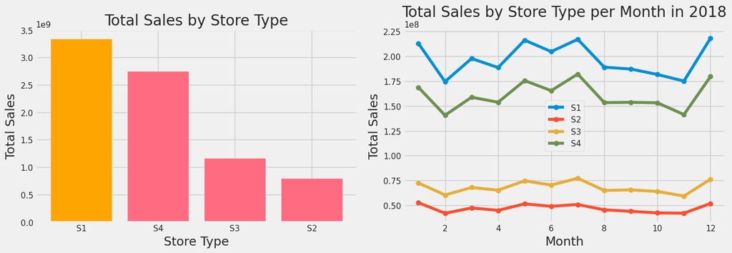

```python
# Total Sales By Store Type
plt.figure(figsize=(14, 5))

# Subplot 1: Total Sales By Store Type
plt.subplot(1, 2, 1)
sales_by_store_type = dataset_raw.groupby('store_type')['sales'].sum()
sales_by_store_type = sales_by_store_type.sort_values(ascending=False)
plt.bar(sales_by_store_type.index, sales_by_store_type.values, color='#ff6b81')
max_sales = sales_by_store_type.max()
max_index = sales_by_store_type.idxmax()
plt.bar(max_index, max_sales, color='#ffa502')
plt.xlabel('Store Type')
plt.ylabel('Total Sales')
plt.title('Total Sales by Store Type')
plt.grid(True)

# Subplot 2: Total Sales by Store Type per Month in 2018
plt.subplot(1, 2, 2)
df_2018 = dataset_raw[dataset_raw['year'] == 2018]
sales_by_store_type_month_2018 = df_2018.groupby(['month', 'store_type'])['sales'].sum().unstack()
for store_type in sales_by_store_type_month_2018.columns:
    plt.plot(sales_by_store_type_month_2018.index, sales_by_store_type_month_2018[store_type], marker='o', label=store_type)
plt.xlabel('Month')
plt.ylabel('Total Sales')
plt.title('Total Sales by Store Type per Month in 2018')
plt.legend()
plt.grid(True)

# Adjust layout
plt.tight_layout()

# Show plot
plt.show()
```

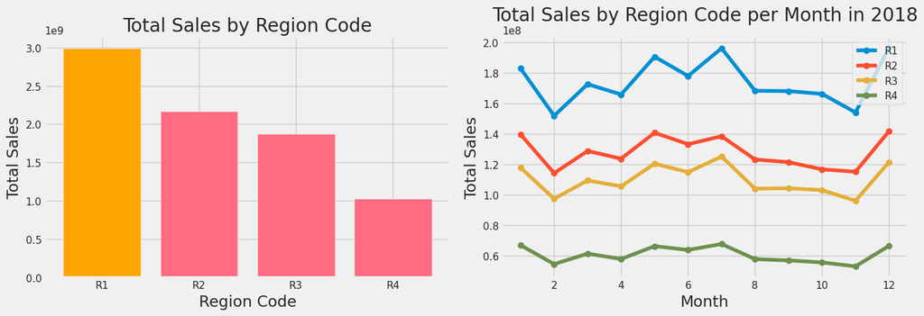

```python
# Total Sales By Region Code
plt.figure(figsize=(14, 5))

# Subplot 1: Total Sales By Region Code
plt.subplot(1, 2, 1)
sales_by_region_code = dataset_raw.groupby('region_code')['sales'].sum()
sales_by_region_code = sales_by_region_code.sort_values(ascending=False)
plt.bar(sales_by_region_code.index, sales_by_region_code.values, color='#ff6b81')
max_sales = sales_by_region_code.max()
max_index = sales_by_region_code.idxmax()
plt.bar(max_index, max_sales, color='#ffa502')
plt.xlabel('Region Code')
plt.ylabel('Total Sales')
plt.title('Total Sales by Region Code')
plt.grid(True)

# Subplot 2: Total Sales by Region Code per Month in 2018
plt.subplot(1, 2, 2)
df_2018 = dataset_raw[dataset_raw['year'] == 2018]
sales_by_region_code_month_2018 = df_2018.groupby(['month', 'region_code'])['sales'].sum().unstack()
for region_code in sales_by_region_code_month_2018.columns:
    plt.plot(sales_by_region_code_month_2018.index, sales_by_region_code_month_2018[region_code], marker='o', label=region_code)
plt.xlabel('Month')
plt.ylabel('Total Sales')
plt.title('Total Sales by Region Code per Month in 2018')
plt.legend()
plt.grid(True)

# Adjust layout
plt.tight_layout()

# Show plot
plt.show()
```

There are differences in the volume of sales between regions. Some regions consistently have higher sales compared to others.

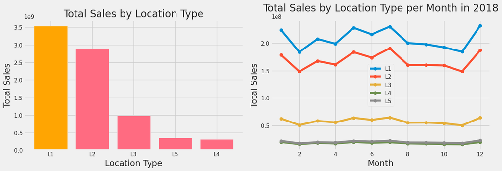

```python
# Total Sales By Location Type
plt.figure(figsize=(14, 5))

# Subplot 1: Total Sales By Location Type
plt.subplot(1, 2, 1)
sales_by_location_type = dataset_raw.groupby('location_type')['sales'].sum()
sales_by_location_type = sales_by_location_type.sort_values(ascending=False)
plt.bar(sales_by_location_type.index, sales_by_location_type.values, color='#ff6b81')
max_sales = sales_by_location_type.max()
max_index = sales_by_location_type.idxmax()
plt.bar(max_index, max_sales, color='#ffa502')
plt.xlabel('Location Type')
plt.ylabel('Total Sales')
plt.title('Total Sales by Location Type')
plt.grid(True)

# Subplot 2: Total Sales by Location Type per Month in 2018
plt.subplot(1, 2, 2)
df_2018 = dataset_raw[dataset_raw['year'] == 2018]
sales_by_location_type_month_2018 = df_2018.groupby(['month', 'location_type'])['sales'].sum().unstack()
for location_type in sales_by_location_type_month_2018.columns:
    plt.plot(sales_by_location_type_month_2018.index, sales_by_location_type_month_2018[location_type], marker='o', label=location_type)
plt.xlabel('Month')
plt.ylabel('Total Sales')
plt.title('Total Sales by Location Type per Month in 2018')
plt.legend()
plt.grid(True)

# Adjust layout
plt.tight_layout()

# Show plot
plt.show()
```

Location types L1 and L2 consistently have higher sales compared to L3, L4, and L5. L1 and L2 typically exhibit the highest sales figures, followed by a decline in sales for L3, L4, and L5.

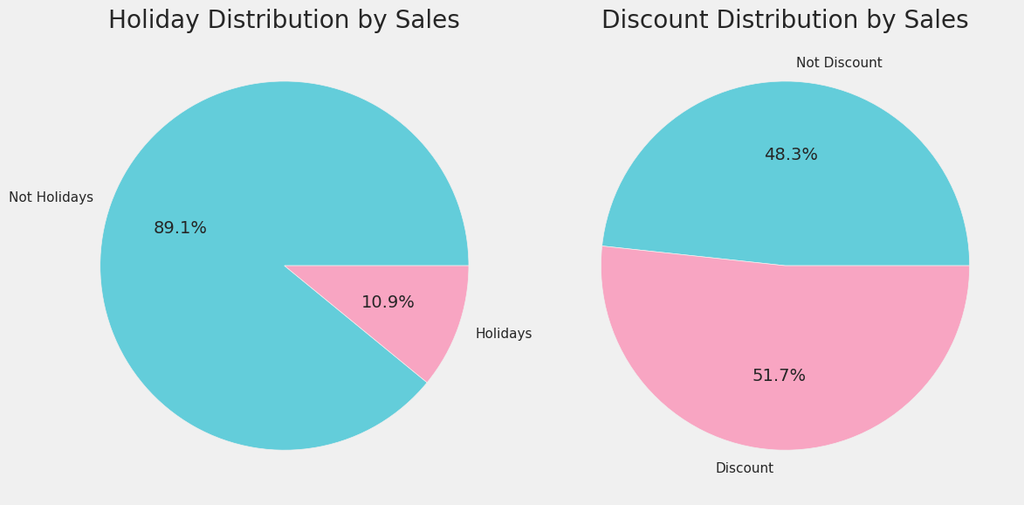

```python
#Holiday & Discount Distribution by Sales
plt.figure(figsize=(12, 6))

# Subplot 1: Distribusi Penjualan berdasarkan Hari Libur
plt.subplot(1, 2, 1)
sales_by_holiday = dataset_raw.groupby('holiday')['sales'].sum()
plt.pie(sales_by_holiday.values, labels=['Not Holidays', 'Holidays'], colors=['#63cdda', '#f8a5c2'], autopct='%1.1f%%')
plt.title('Holiday Distribution by Sales')

# Subplot 2: Distribusi Penjualan berdasarkan Diskon
plt.subplot(1, 2, 2)
sales_by_discount = dataset_raw.groupby('discount')['sales'].sum()
plt.pie(sales_by_discount.values, labels=['Not Discount', 'Discount'], colors=['#63cdda', '#f8a5c2'], autopct='%1.1f%%')
plt.title('Discount Distribution by Sales')

plt.tight_layout()
plt.show()
```

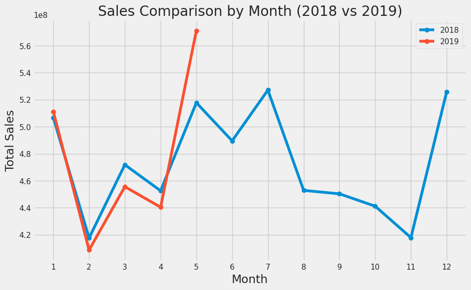

```python
df = dataset_raw

# Slicing data untuk tahun 2018 dan 2019
df_2018 = df[df['year'] == 2018]
df_2019 = df[df['year'] == 2019]

# Mengelompokkan penjualan berdasarkan bulan untuk masing-masing tahun
sales_by_month_2018 = df_2018.groupby('month')['sales'].sum()
sales_by_month_2019 = df_2019.groupby('month')['sales'].sum()

# Membuat plot
plt.figure(figsize=(10, 6))
plt.plot(sales_by_month_2018.index, sales_by_month_2018.values, marker='o', label='2018')
plt.plot(sales_by_month_2019.index, sales_by_month_2019.values, marker='o', label='2019')
plt.xlabel('Month')
plt.ylabel('Total Sales')
plt.title('Sales Comparison by Month (2018 vs 2019)')
plt.xticks(range(1, 13))
plt.legend()
plt.grid(True)
plt.show()
```

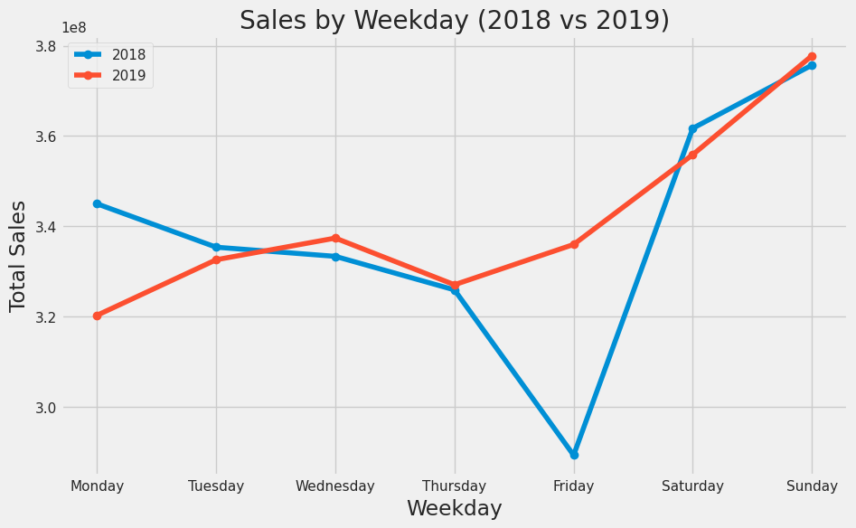

```python
# Sales by Weekday
df_2018 = df.loc[(df['year'] == 2018) & (df['month'].between(1, 5))]

df_2019 =  df.loc[(df['year'] == 2019) & (df['month'].between(1, 5))]

# Mengelompokkan penjualan berdasarkan hari dalam seminggu untuk tahun 2018
sales_by_weekday_2018 = df_2018.groupby('day_of_week')['sales'].sum()
# Mengelompokkan penjualan berdasarkan hari dalam seminggu untuk tahun 2019
sales_by_weekday_2019 = df_2019.groupby('day_of_week')['sales'].sum()

# Membuat plot garis untuk tahun 2018
plt.figure(figsize=(10, 6))
plt.plot(sales_by_weekday_2018.index, sales_by_weekday_2018.values, marker='o', label='2018')

# Membuat plot garis untuk tahun 2019
plt.plot(sales_by_weekday_2019.index, sales_by_weekday_2019.values, marker='o', label='2019')

plt.xlabel('Weekday')
plt.ylabel('Total Sales')
plt.title('Sales by Weekday (2018 vs 2019)')
plt.xticks(range(7), ['Monday', 'Tuesday', 'Wednesday', 'Thursday', 'Friday', 'Saturday', 'Sunday'])
plt.legend()
plt.grid(True)
plt.show()
```

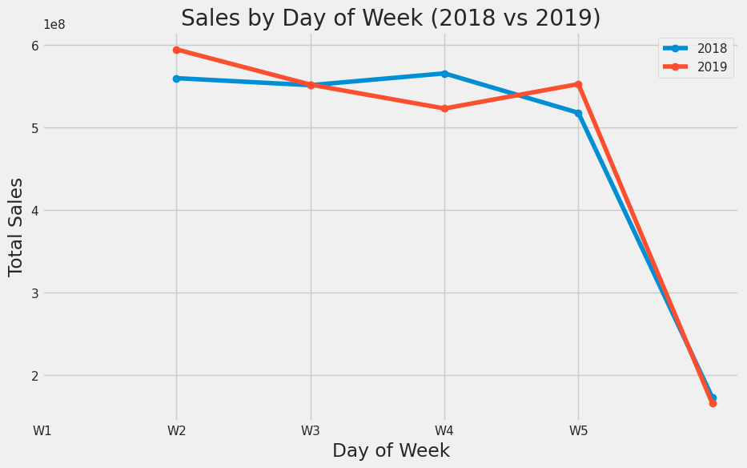

```python
# Sales by Weekday
df_2018 = df.loc[(df['year'] == 2018) & (df['month'].between(1, 5))]

df_2019 =  df.loc[(df['year'] == 2019) & (df['month'].between(1, 5))]

# Mengelompokkan penjualan berdasarkan hari dalam seminggu untuk tahun 2018
sales_by_weekday_2018 = df_2018.groupby('week')['sales'].sum()
# Mengelompokkan penjualan berdasarkan hari dalam seminggu untuk tahun 2019
sales_by_weekday_2019 = df_2019.groupby('week')['sales'].sum()

# Membuat plot garis untuk tahun 2018
plt.figure(figsize=(10, 6))
plt.plot(sales_by_weekday_2018.index, sales_by_weekday_2018.values, marker='o', label='2018')

# Membuat plot garis untuk tahun 2019
plt.plot(sales_by_weekday_2019.index, sales_by_weekday_2019.values, marker='o', label='2019')

plt.xlabel('Day of Week')
plt.ylabel('Total Sales')
plt.title('Sales by Day of Week (2018 vs 2019)')
plt.xticks(range(5), ['W1', 'W2', 'W3', 'W4', 'W5'])
plt.legend()
plt.grid(True)
plt.show()
```

**Distribution and Outlier**

```python
# Convert back feature to integer
dataset_raw[['store_id','holiday', 'discount']] = dataset_raw[['store_id', 'holiday', 'discount']].astype(int)
```

```python
# Data types
print('Data type per variable:')
print(dataset_raw.dtypes)
```

```
Data type per variable:
store_id                  int64
store_type               object
location_type            object
region_code              object
date             datetime64[ns]
holiday                   int64
discount                  int64
order                     int64
sales                   float64
year                      int64
month                     int64
day_of_week               int64
week                      int64
quarter                   int64
dtype: object
```

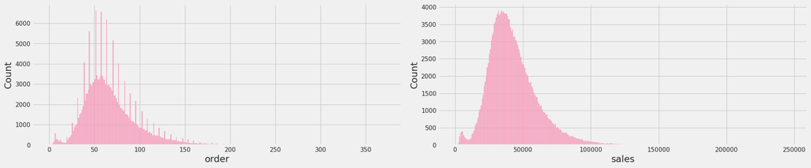

```python
#Distribusi on Feature Order & Sales
def plot_distribution(data):
    features = ['order', 'sales']
    for i in range(0, len(features)):
        plt.subplot(2, 2, i+1)
        sns.histplot(x=data[features[i]], color='#f78fb3')
        plt.xlabel(features[i])

    plt.tight_layout()

plot_distribution(dataset_raw)
```

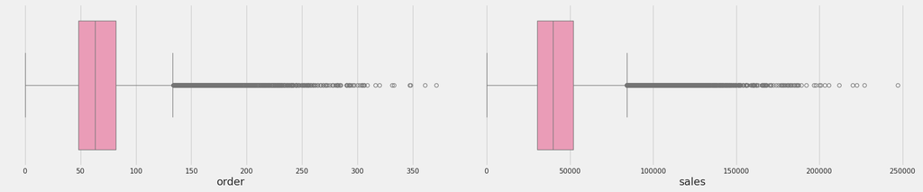

```python
#Outlier on Feature Order & Sales
def plot_outliner(data):
    features = ['order', 'sales']
    plt.subplots_adjust(hspace=0.5)
    for i in range(0, len(features)):
        plt.subplot(2, 2, i+1)
        sns.boxplot(x=data[features[i]], color='#f78fb3')
        plt.xlabel(features[i])
        plt.tight_layout()

plot_outliner(dataset_raw)
```

**Feature Engineering**

```python
# Dealing with the outlier
def handling_outlier(dataset, feature):
  for f in feature:
    q1 = dataset[f].quantile(0.25)
    q3 = dataset[f].quantile(0.75)
    iqr = q3-q1
    Lower_tail = q1 - 1.5 * iqr
    Upper_tail = q3 + 1.5 * iqr
    med = np.median(dataset[f])
    for i in dataset[f]:
        if i > Upper_tail or i < Lower_tail:
                dataset[f] = dataset[f].replace(i, med)

handling_outlier(dataset_raw, ['sales','order'])
```

```python
#Menghapus Outlier pada distribusi Normal
from scipy import stats

print("Before removing outlier: ", len(dataset_raw))

for num in ['sales','order']:
  z_scores = np.abs(stats.zscore(dataset_raw[num]))
  dataset_raw = dataset_raw[z_scores <= 3]

print("After removing outlier: ", len(dataset_raw))
```

```
Before removing outlier:  188340
After removing outlier:  188340
```

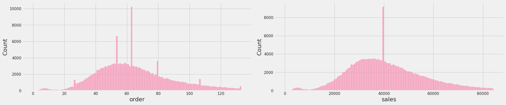

```python
#Check Distribution
plot_distribution(dataset_raw)
```

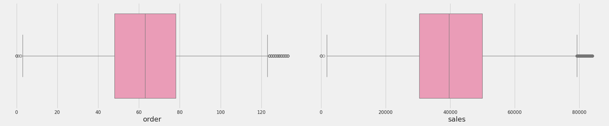

```python
#Check Outlier
plot_outliner(dataset_raw)
```

```python
from sklearn.preprocessing import MinMaxScaler
#Normalisasi Target Feature
dataset_raw['sales'] = MinMaxScaler().fit_transform(np.array(dataset_raw['sales']).reshape(-1,1))
```

```python
# Do One Hot Encoding to column with object data type
dataset_raw = pd.get_dummies(dataset_raw, columns=['store_type','location_type','region_code'], drop_first=True)   # One hot encoding
dataset_raw.info()
```

```
<class 'pandas.core.frame.DataFrame'>
Int64Index: 188340 entries, 0 to 188339
Data columns (total 21 columns):
 #   Column            Non-Null Count   Dtype
---  ------            --------------   -----
 0   store_id          188340 non-null  int64
 1   date              188340 non-null  datetime64[ns]
 2   holiday           188340 non-null  int64
 3   discount          188340 non-null  int64
 4   order             188340 non-null  int64
 5   sales             188340 non-null  float64
 6   year              188340 non-null  int64
 7   month             188340 non-null  int64
 8   day_of_week       188340 non-null  int64
 9   week              188340 non-null  int64
 10  quarter           188340 non-null  int64
 11  store_type_S2     188340 non-null  uint8
 12  store_type_S3     188340 non-null  uint8
 13  store_type_S4     188340 non-null  uint8
 14  location_type_L2  188340 non-null  uint8
 15  location_type_L3  188340 non-null  uint8
 16  location_type_L4  188340 non-null  uint8
 17  location_type_L5  188340 non-null  uint8
 18  region_code_R2    188340 non-null  uint8
 19  region_code_R3    188340 non-null  uint8
 20  region_code_R4    188340 non-null  uint8
dtypes: datetime64[ns](1), float64(1), int64(9), uint8(10)
memory usage: 19.0 MB
```

```
[]
```

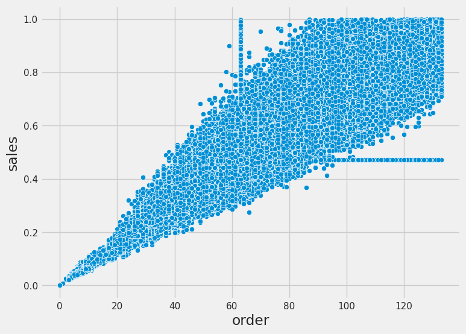

```python
#Strength correlation between order and sales
plt.figure(figsize=(8, 6))
ax = sns.scatterplot(x="order", y="sales", data=dataset_raw)
plt.plot()
```

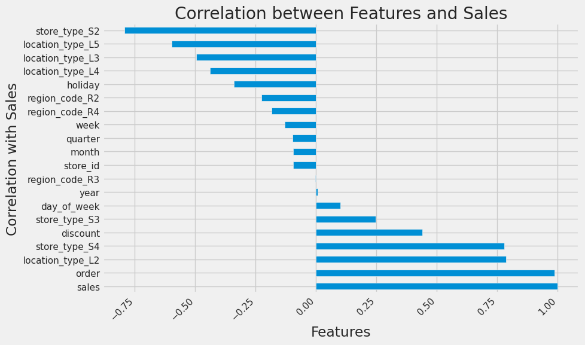

```python
import seaborn as sns
correlation_matrix = dataset_raw.corr()

# Count correlation between feature and label
correlation = correlation_matrix.corr()['sales'].sort_values(ascending=False)

# Memvisualisasikan korelasi
plt.figure(figsize=(10, 6))
correlation.plot(kind='barh')
plt.xlabel('Features')
plt.ylabel('Correlation with Sales')
plt.title('Correlation between Features and Sales')
plt.xticks(rotation=45, ha='right')
plt.tight_layout()
plt.show()
```

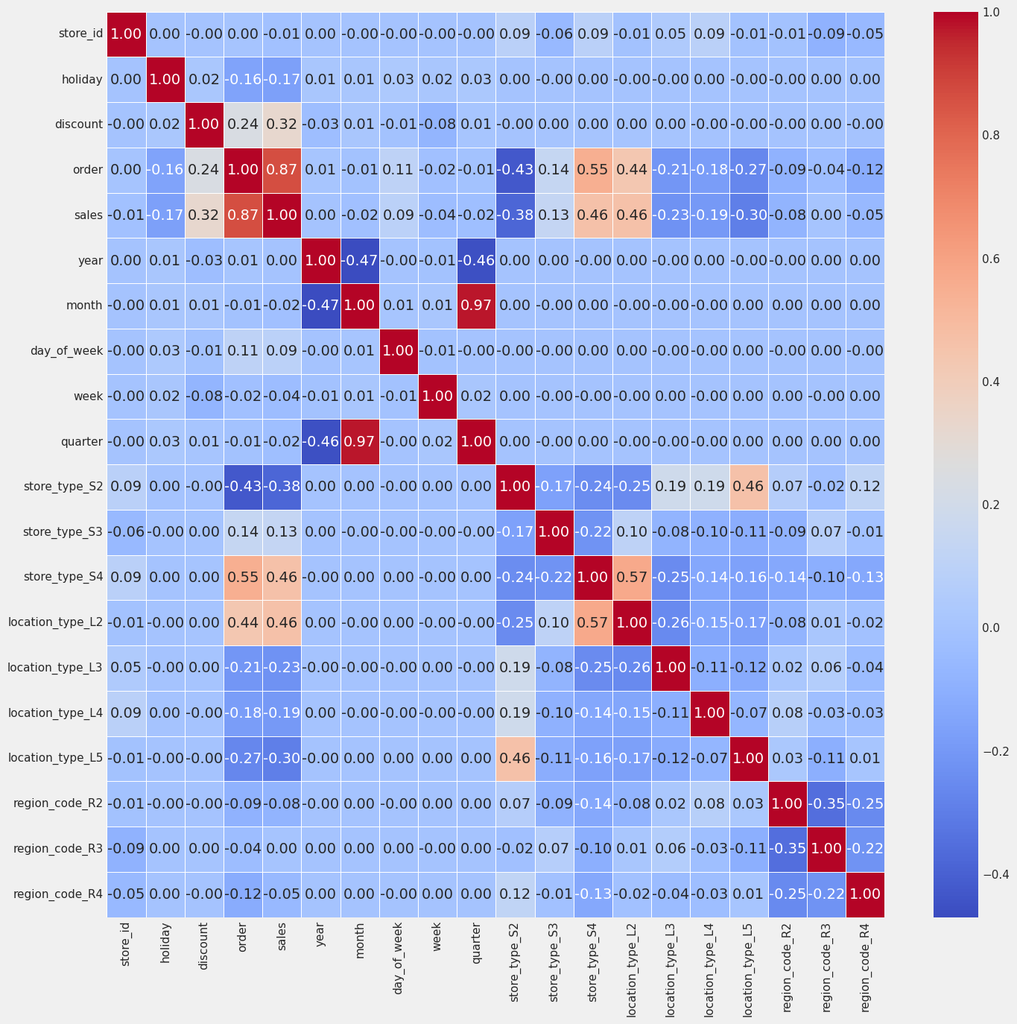

```python
#Heatmap
plt.figure(figsize=(15,15))
sns.heatmap(correlation_matrix,annot=True,linewidths=0.7,fmt=".2f",cmap="coolwarm")
plt.show()
```

# Prediction Model

**Feature Important**

```python
# Define Feature and Label
clean_df = dataset_raw.drop(['store_id','year','date','region_code_R3'],axis=1)
sales_df = dataset_raw.copy() #for arima model

y = clean_df['sales']
x = clean_df.drop(['sales','order'],axis=1)
```

```python
from sklearn.ensemble import RandomForestRegressor

rf_model = RandomForestRegressor()
rf_model.fit(x, y)
feature_importance = rf_model.feature_importances_
feature_importance_df = pd.DataFrame({'Feature': x.columns, 'Importance': feature_importance})
# feature_importance_df
```

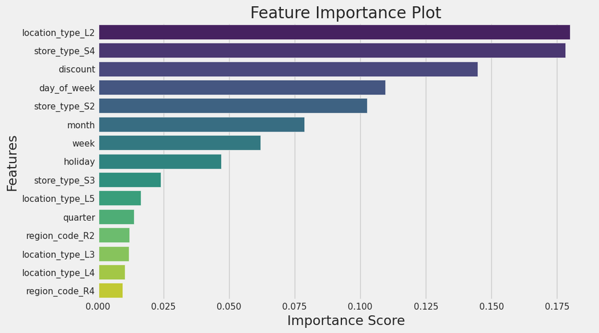

```python
#Visualize Feature Important
sorted_df = feature_importance_df.sort_values(by='Importance', ascending=False)

plt.figure(figsize=(10, 6))
sns.barplot(x='Importance', y='Feature', data=sorted_df, palette='viridis')
plt.xlabel('Importance Score')
plt.ylabel('Features')
plt.title('Feature Importance Plot')
plt.show()
```

```python
#Splitting data 80:20
from sklearn.model_selection import train_test_split
X_train, X_test, y_train, y_test = train_test_split(x,y,test_size=0.2, random_state=42)
```

**Modeling**

```python
# !pip install xgboost
# !pip install lightgbm
!pip install catboost
```

```
     ━━━━━━━━━━━━━━━━━━━━━━━━━━━━━━━━━━━━━━━━ 98.5/98.5 MB 4.6 MB/s eta 0:00:00
```

```python
import pandas as pd
from sklearn.metrics import mean_squared_error, mean_absolute_error, r2_score
from sklearn.linear_model import LinearRegression, Ridge, Lasso, ElasticNet, LassoCV, ElasticNetCV
from sklearn.neighbors import KNeighborsRegressor
from sklearn.neural_network import MLPRegressor
from catboost import CatBoostRegressor
from lightgbm import LGBMRegressor
from xgboost import XGBRegressor
from sklearn.tree import DecisionTreeRegressor
from sklearn.neighbors import KNeighborsRegressor
from sklearn.ensemble import RandomForestRegressor
from sklearn.ensemble import GradientBoostingRegressor
from sklearn.ensemble import AdaBoostRegressor
import pickle

regression_models = [
    (LinearRegression(), 'LinearRegression'),
    (Ridge(), 'RidgeRegression'),
    (Lasso(), 'LassoRegression'),
    (ElasticNet(), 'ElasticNetRegression'),
    (LassoCV(), 'LassoCVRegression'),
    (ElasticNetCV(), 'ElasticNetCVRegression'),
    (DecisionTreeRegressor(), 'DecisionTreeRegressor'),
    (RandomForestRegressor(), 'RandomForestRegressor'),
    (AdaBoostRegressor(), 'AdaBoostRegressor'),
    (LGBMRegressor(), 'LGBMRegressor'),
    (GradientBoostingRegressor(), 'GradientBoostingRegressor'),
    (XGBRegressor(), 'XGBoostRegression'),
    (CatBoostRegressor(), 'CatBoostRegressor'),
    # (KNeighborsRegressor(), 'KNeighbors Regression'), # too long
    # (MLPRegressor(), 'MLP Regression'), # too long
]

results = []

for model, label in regression_models:
    print("Progress ", label)
    model.fit(X_train, y_train)
    with open('models/'+label+'_model.pkl', 'wb') as f:
      pickle.dump(model, f)
    y_pred = model.predict(X_test)

    mse = mean_squared_error(y_test, y_pred)
    mae = mean_absolute_error(y_test, y_pred)
    r2 = r2_score(y_test, y_pred)
    results.append([label, mse, mae, r2])

df_results = pd.DataFrame(results, columns=['Model', 'MSE', 'MAE', 'R-squared'])
```

[output not shown]

[output cut: 965 more lines]

[output not shown]

```python
df_results.sort_values('MSE', ascending=False)
```

|  | Model | MSE | MAE | R-squared |
| --- | --- | --- | --- | --- |
| 2 | LassoRegression | 0.032220 | 0.141360 | -0.000058 |
| 3 | ElasticNetRegression | 0.032220 | 0.141360 | -0.000058 |
| 8 | AdaBoostRegressor | 0.018235 | 0.109502 | 0.434018 |
| 5 | ElasticNetCVRegression | 0.015391 | 0.092497 | 0.522296 |
| 4 | LassoCVRegression | 0.015391 | 0.092497 | 0.522297 |
| 0 | LinearRegression | 0.015390 | 0.092497 | 0.522312 |
| 1 | RidgeRegression | 0.015390 | 0.092497 | 0.522312 |
| 10 | GradientBoostingRegressor | 0.013251 | 0.085691 | 0.588704 |
| 6 | DecisionTreeRegressor | 0.011838 | 0.079320 | 0.632584 |
| 9 | LGBMRegressor | 0.011461 | 0.079813 | 0.644287 |
| 7 | RandomForestRegressor | 0.011427 | 0.078165 | 0.645335 |
| 11 | XGBoostRegression | 0.010843 | 0.076751 | 0.663458 |
| 12 | CatBoostRegressor | 0.010807 | 0.076598 | 0.664569 |

**Conslusion**

If we consider MSE and MAE, a **lower value for MSE and MAE indicates better model performance**. In this case, **CatBoost Regressor model has the lowest MSE and MAE value and the highest R-squared value** compared to other models. Based on these metrics, Catboost Regressor is considered the best model in terms of prediction accuracy.

However, if we consider R-squared, a value closer to 1 indicates a better model in explaining the variation in the data. In this case, **CatBoost Regressor also has the highest R-squared value** compared to other models. **This indicates that the CatBoost Regressor model is better at explaining the variation in the data compared to other models**.

Based on the evaluation of MSE, MAE, and R-squared, it can be concluded that the **CatBoost Regression model is the best model in terms of prediction accuracy and its ability to explain the variation in the data**.

```python
# #@title Convert ipynb to HTML in Colab
# # Upload ipynb
# from google.colab import files
# f = files.upload()

# # Convert ipynb to html
# import subprocess
# file0 = list(f.keys())[0]
# _ = subprocess.run(["pip", "install", "nbconvert"])
# _ = subprocess.run(["jupyter", "nbconvert", file0, "--to", "html"])

# # download the html
# files.download(file0[:-5]+"html")
```